# Clustering

70-467 Machine Learning for Business Analytics

Professor: Andrés Castaño Zuluaga

Before we start: work on the four questions in the problem file with the person next to you.

## How should the menu team group the 77 food items?

Which items are alike?

How many kinds of item does the menu have?

Type is the menu category, and one category can hold very different food. The bakery items alone go from a 130-calorie mini doughnut to a 490-calorie loaf.

Can calories, fat, carb, fiber and protein sort the 77 items into a few groups that the team can name and use?

## What do we know about each item?

One observation is one food item: 77 items of 7 types. 41 are bakery items. We set type aside and use it only to check the groups at the end.

| Variable | Type | Unit | Description |
| --- | --- | --- | --- |
| item | text | none | Name on the menu board |
| type | text | none | bakery, bistro box, hot breakfast, parfait, petite, salad or sandwich |
| calories | integer | calories | Energy in one item |
| fat | numeric | g | Fat in one item |
| carb | integer | g | Carbohydrate in one item |
| fiber | integer | g | Fiber in one item |
| protein | integer | g | Protein in one item |

Data: starbucks, OpenIntro. The same file as last session.

There is no outcome to predict. Why not simply group the items by type?

## Where are we on the course roadmap?

|  | Description | Tools | Use |
| --- | --- | --- | --- |
| Predict & evaluate |  |  |  |
| Linear regression | Predict a number | OLS |  |
| Metrics | Size of the errors | RMSE, R² |  |
| Train/test + leakage | Predict without fooling ourselves | Holdout |  |
| Regularization | Shrink complexity | Ridge, lasso |  |
| Cross-validation | Choose λ without touching test | k-fold |  |
| Classify & decide |  |  |  |
| Logistic | A probability, not a class | Log-odds |  |
| Thresholds | A score is not an action | ROC, threshold |  |
| Flexible & unsupervised |  |  |  |
| Trees | When linearity fails | Splits | Split the hours into simple regions. |
| Forests / boosting | One ensemble | Random forest, boosting |  |
| PCA | Compress X, no Y | PCs |  |
| Clustering | Segment without Y | K-means, tree | Sort the menu into groups of similar items. |

What will we do in this topic?

## What we will do

1. What makes two items alike?
2. How does K-means form groups?
3. Why start K-means more than once?
4. Why put the numbers in standard deviations?
5. How many groups should we keep?
6. Is there another way to build groups, and does it agree?

## What makes two items alike?

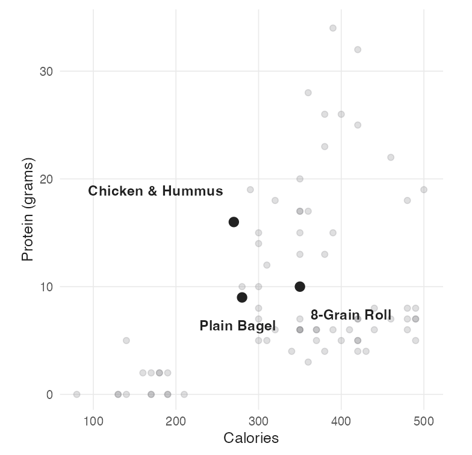

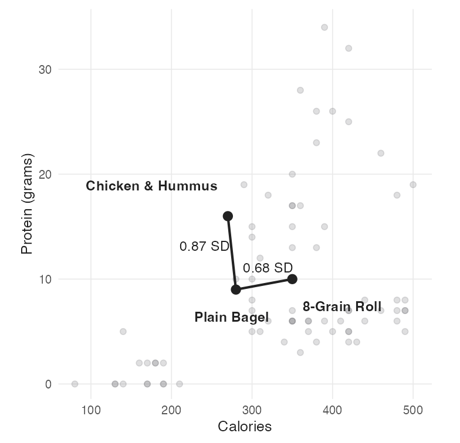

The picture shows calories and protein in their own units. The clustering itself uses all five numbers, in standard deviations.

|  | calories | protein (g) | calories vs bagel | protein vs bagel |
| --- | --- | --- | --- | --- |
| Plain Bagel | 280 | 9 |  |  |
| 8-Grain Roll | 350 | 10 | +70 | +1 |
| Chicken & Hummus | 270 | 16 | −10 | +7 |

Which item is closer to the Plain Bagel: the 8-Grain Roll or Chicken & Hummus?

Euclidean distance between items $i$ and $i'$: $\sqrt{\sum_{j=1}^{p} (x_{ij} - x_{i'j})^2}$

In SDs, bagel to roll: $\sqrt{0.664^2 + 0.124^2} = 0.68$. Bagel to Chicken & Hummus: $\sqrt{0.095^2 + 0.866^2} = 0.87$.

On all five numbers in SDs: 1.92 to the roll, 2.93 to Chicken & Hummus.

In the file’s units, Chicken & Hummus is closer: 12.2 against 70.0. Ten calories count the same as ten grams.

## Where would you draw four groups?

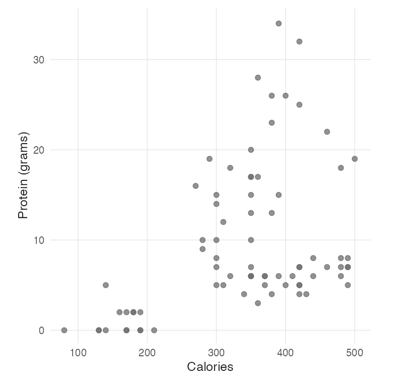

The picture shows calories and protein in their own units. The clustering itself uses all five numbers, in standard deviations.

Draw four groups on the picture. Which items were hard to place?

## How does a simple rule form four groups?

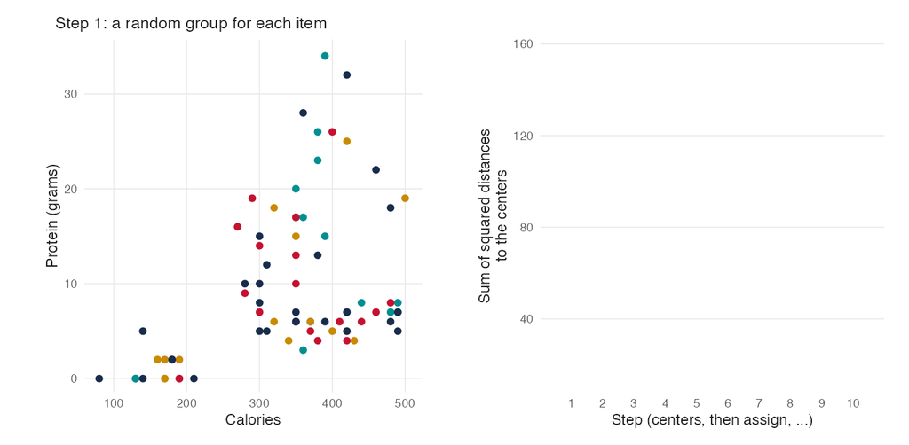

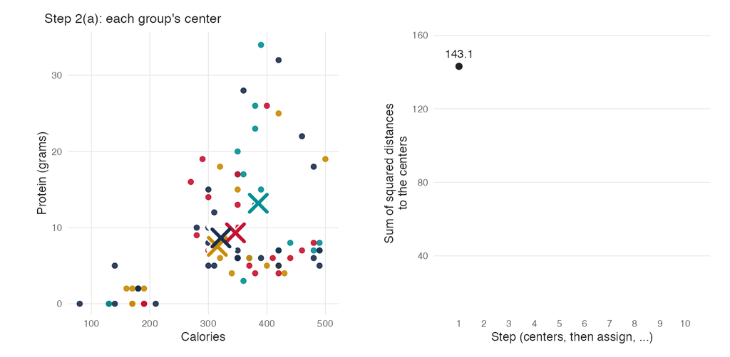

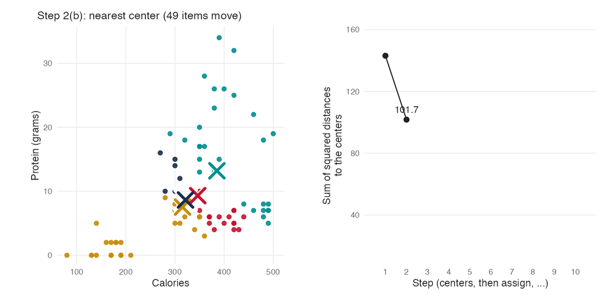

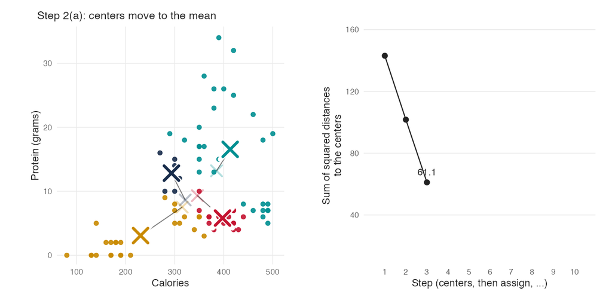

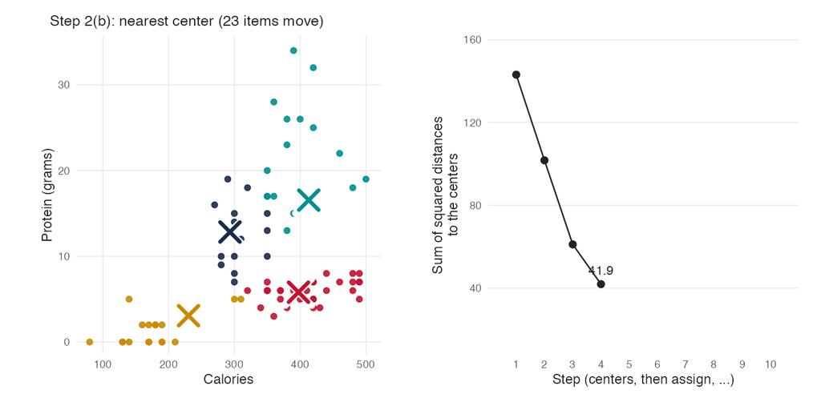

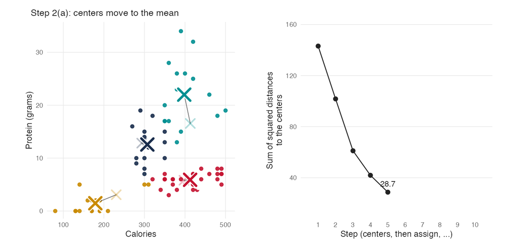

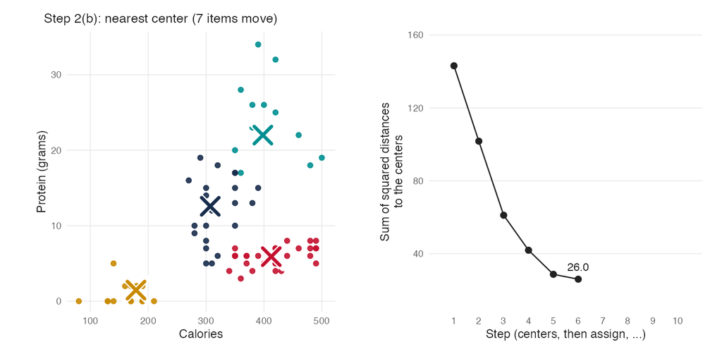

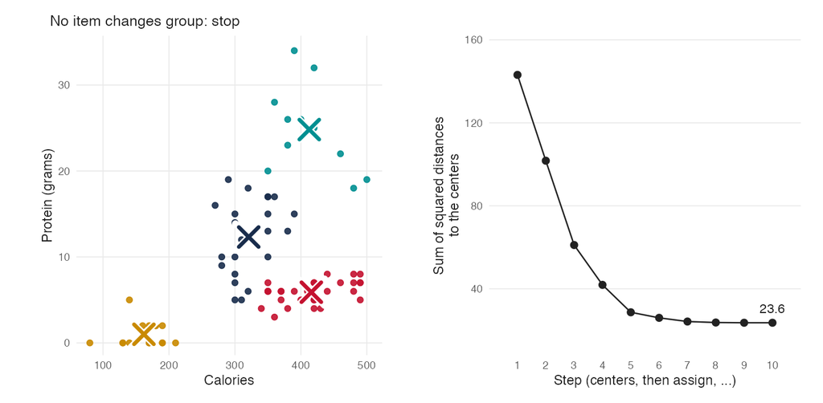

The picture shows calories and protein in their own units. On this slide the groups use only these two numbers, in standard deviations.

Each item joins its nearest cross. Then each cross moves to the center of its group. What happens to the total on the right?

**K-means clustering** (ISLR Algorithm 12.2, in short)

1. Give each item a random group from 1 to K.

2. Repeat until no item changes group: (a) compute each group’s center (centroid), the mean of its items; (b) move each item to the group with the nearest center (straight-line distance).

Menu, two numbers, K = 4: the total falls from 143.11 to 23.62. Items moved: 49, 23, 7, 1, then 0.

## Does a second start end in the same place?

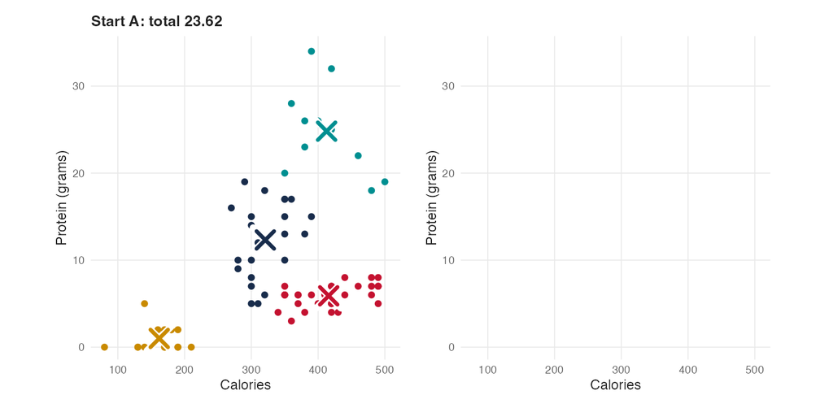

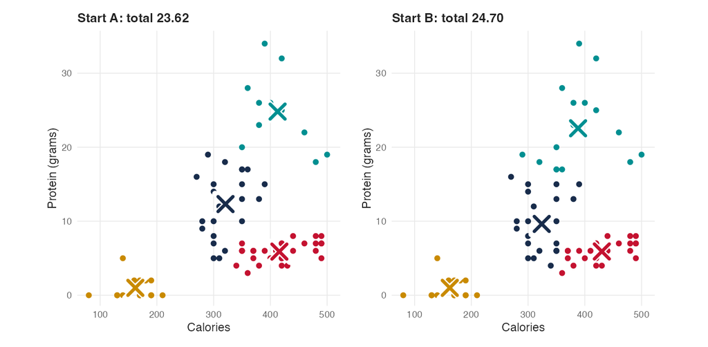

The pictures show calories and protein in their own units. On this slide the groups use only these two numbers, in standard deviations.

Start B begins from another random coloring. Will it stop at the same four groups?

`tot.withinss` is the total within-group sum of squares, the number K-means tries to make small (ISLR 12.5.3). “We strongly recommend always running K-means clustering with a large value of nstart, such as 20 or 50, since otherwise an undesirable local optimum may be obtained.” (ISLR 12.5.3)

$$\sum_{k=1}^{K} \sum_{i \in C_k} \sum_{j=1}^{p} (x_{ij} - \bar{x}_{kj})^2$$

$C_k$ is the items in group $k$, $p$ the number of variables, and $\bar{x}_{kj}$ group $k$’s mean on variable $j$. R reports this number as tot.withinss.

Here, kmeans() with nstart = 1 reaches 23.62 in 15 of 100 runs. With nstart = 20 it keeps the best of 20 starts and reaches 23.62 in 98 of 100 runs.

## What changes with all five numbers?

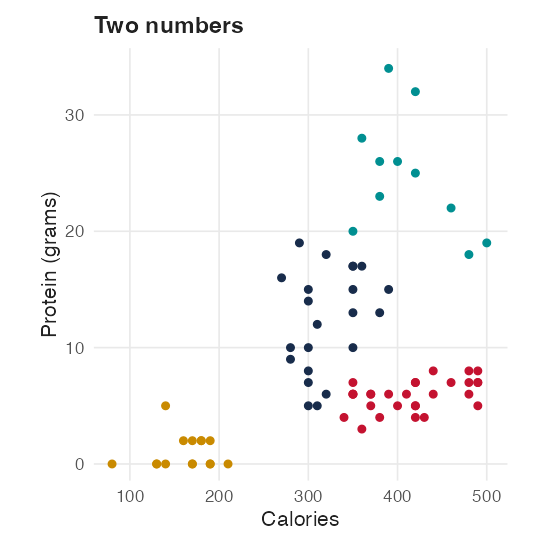

Now the groups use all five numbers. Will any item change group?

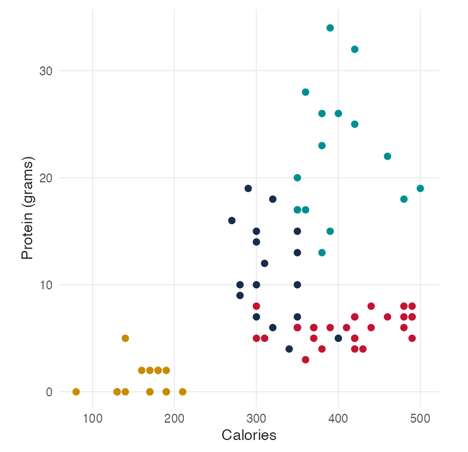

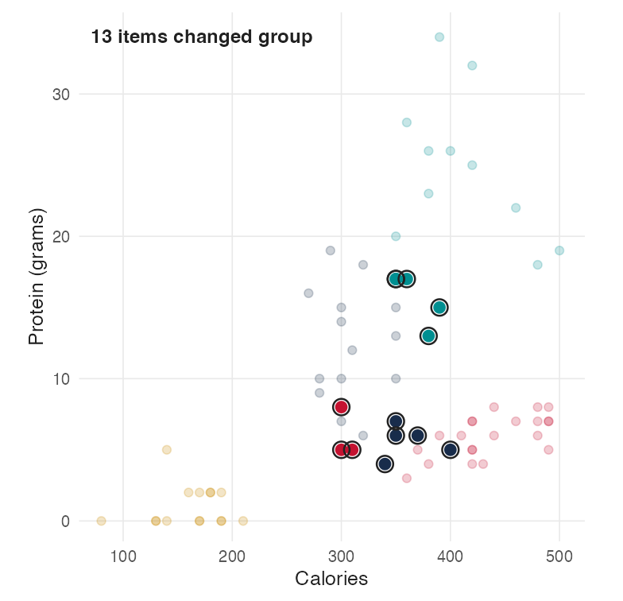

The picture shows calories and protein in their own units. The clustering itself uses all five numbers, in standard deviations.

## Does the unit decide the groups?

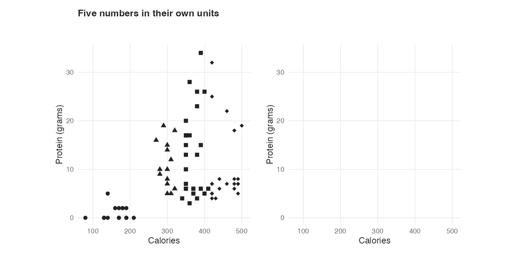

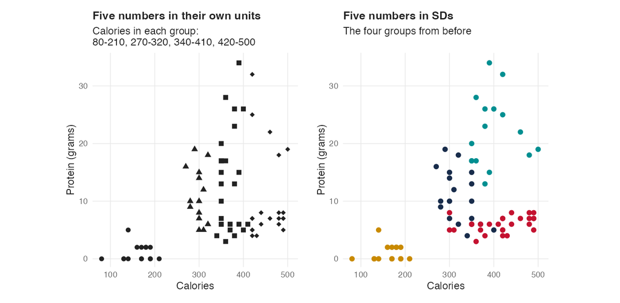

Both pictures show calories and protein in their own units. The groups use all five numbers: on the left in the file’s units, on the right in standard deviations.

Without SDs, every number keeps the unit in the file. Which number decides the groups on the left?

z-score: $z = (x - \text{mean}) / \text{SD}$. Plain Bagel: (280 − 338.8) / 105.4 = −0.56. In R, scale() does this to every number.

## How many groups should we keep?

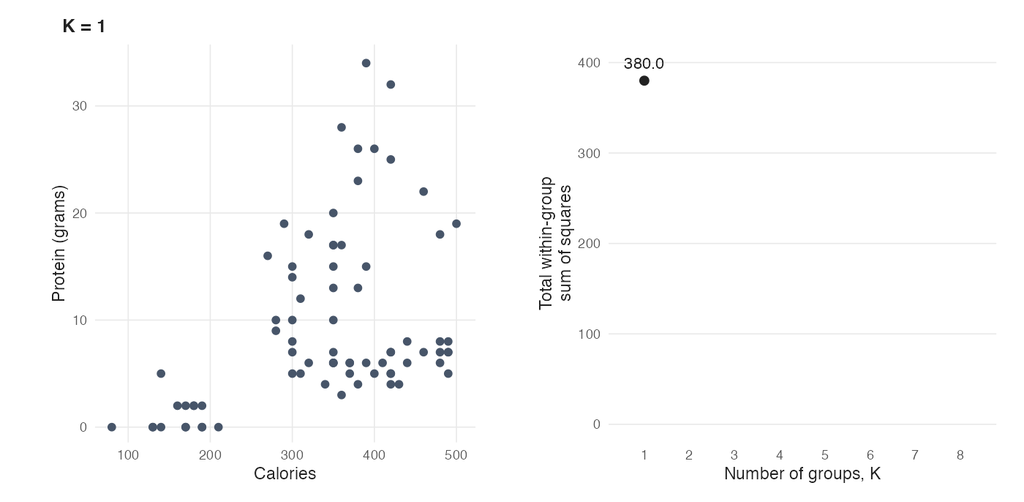

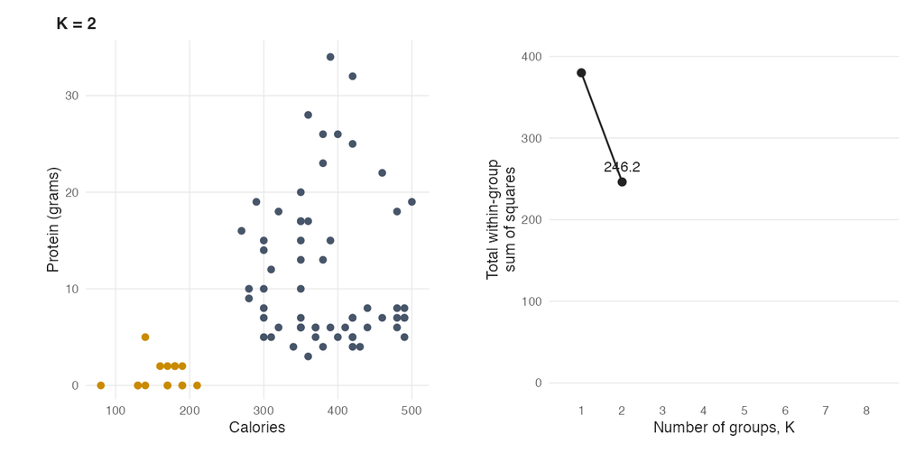

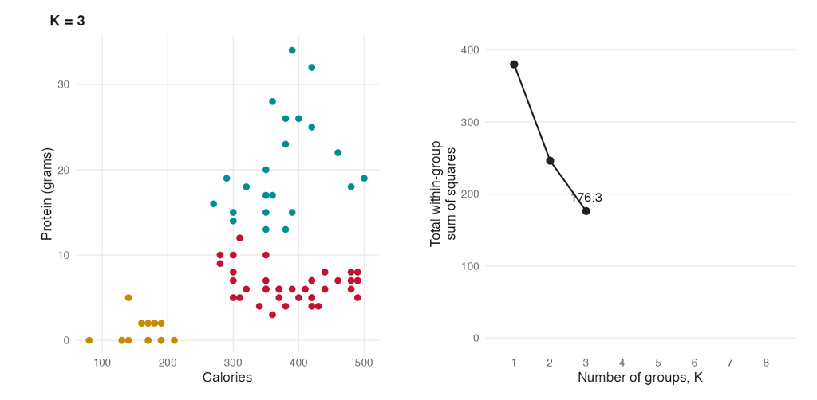

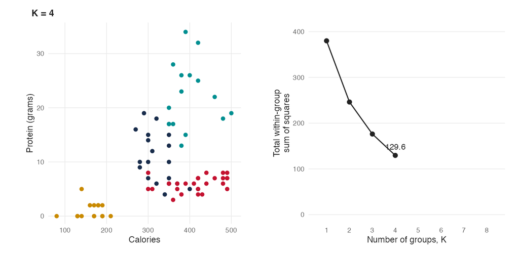

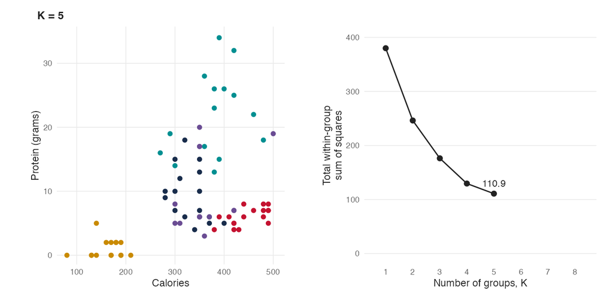

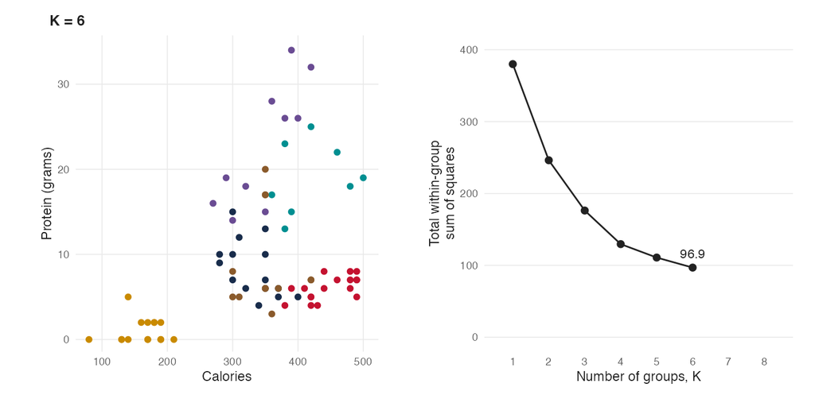

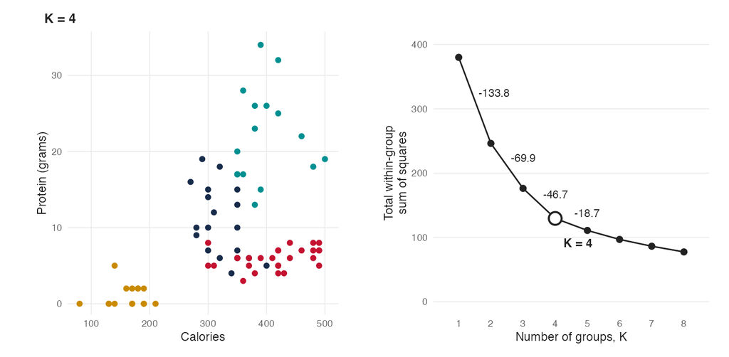

The picture shows calories and protein in their own units. The clustering itself uses all five numbers, in standard deviations.

Each extra group lowers the total. Where would you stop?

This curve is an **elbow plot**: the total within-group sum of squares for each K. Stop where the next group lowers the total by much less.

Drops: 133.8, 69.9, 46.7, then 18.7. The drop from 4 to 5 groups is 40% of the drop from 3 to 4.

## Does a second check agree?

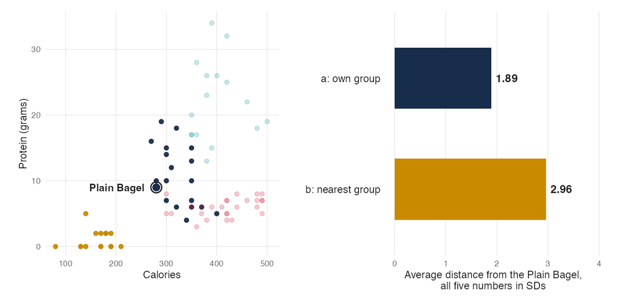

[figure not shown]

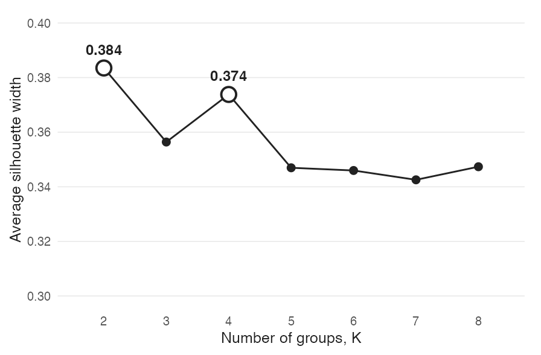

Silhouette of item $i$: $s(i) = \dfrac{b(i) - a(i)}{\max\{a(i), b(i)\}}$, with $a(i)$ its average distance to the other items in its group and $b(i)$ to the nearest other group.

Plain Bagel: (2.96 − 1.89) / 2.96 = 0.36. Near 1: well placed. Near 0 or below: on the edge.

Average s(i) over all 77 items for each K. Which K will score highest?

K = 2 is highest, 0.384. K = 4 is 0.374, only 0.010 lower. K = 2 splits the 15 smallest items from the other 62.

## What are the four groups, in plain words?

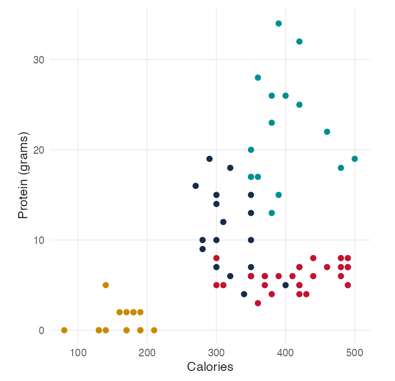

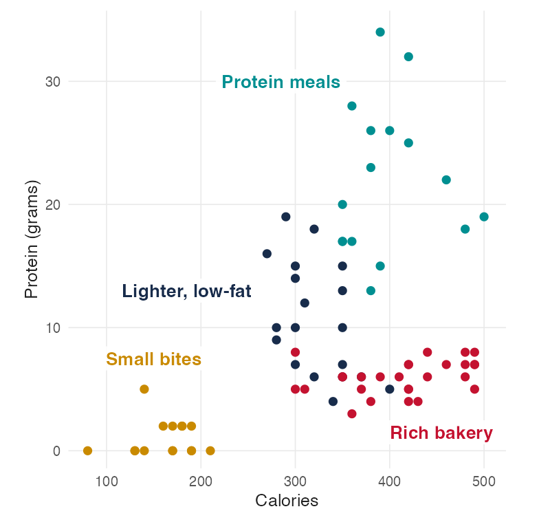

The picture shows calories and protein in their own units. The clustering itself uses all five numbers, in standard deviations.

Group means

| Group | items | calories | fat (g) | carb (g) | fiber (g) | protein (g) |
| --- | --- | --- | --- | --- | --- | --- |
| ______Small bites | 15 | 162.0 | 7.2 | 23.5 | 0.4 | 1.0 |
| ______Lighter, low-fat | 19 | 322.6 | 7.7 | 53.3 | 4.2 | 10.6 |
| ______Rich bakery | 27 | 413.3 | 18.7 | 56.1 | 1.4 | 6.0 |
| ______Protein meals | 16 | 398.1 | 18.7 | 35.9 | 3.1 | 22.0 |
| Menu | 77 | 338.8 | 13.8 | 44.9 | 2.2 | 9.5 |

With your neighbor, two minutes: name each group in two or three words. Do any names from question 3 fit?

Check with type, which K-means never saw: Small bites holds all 9 petites. Rich bakery is 26 bakery items and 1 parfait. Protein meals is 6 bistro boxes, 4 hot breakfasts and 6 sandwiches.